# 2 - Noise correction and genotype labeling

This is the second part of the tutorial for processing [GoT-ChA](https://www.biorxiv.org/content/10.1101/2022.05.11.491515v1) genotyping libraries. The Gotcha R package required for this tutorial can be downloaded [here](https://github.com/landau-lab/Gotcha/tree/main).

### Use of GotchaLabeling function

This is the second part of the pipeline, which starts from the wild type and mutant read counts as obtained in the *“1- How to run Gotcha in slurm clusters with parallel computing”* tutorial shown [here](https://github.com/landau-lab/Gotcha/blob/development/Running%20Gotcha%20with%20parallel%20computing%20in%20slurm.pdf).

First, we load the Gotcha R package and other packages required for this tutorial:

```r
library(Gotcha)
```

To perform the noise correction and genotype assignment, we run the *GotchaLabeling* function. This can be run on the full list of detected barcodes (including both empty droplets and true cells). This takes longer, but can help identify the cluster of non-genotyped cells when performing the cluster assignment. Here, we run the function only on barcodes that were assigned as true cells based on the scATAC-seq data. The data used as input is generated by the *BatchMutationCalling* function followed by the *MergeGotchaOuts* function, as shown in the “Running Gotcha with parallel computing in slurm” tutorial.

The metadata used as input should contain the following columns: Sample, GeneName_WTcount, and GeneName_MUTcount as shown below:

| X | Sample | TP53_WTcount | TP53_MUTcount |
| --- | --- | --- | --- |
| RM30#AACATCGAGGCCTCGT-1 | RM30 | 2383 | 136 |
| RM30#CCCACATAGGCGATTG-1 | RM30 | 112 | 2920 |
| RM30#CAGCTAATCTATCCTA-1 | RM30 | 311 | 771 |
| RM30#GCACGGTGTCGAGGAT-1 | RM30 | 548 | 2582 |
| RM30#CCAATGACAGGCAGAT-1 | RM30 | 214 | 17655 |
| RM30#TTGTTGTCAGGTAACG-1 | RM30 | 251 | 493 |

To run the *GotchaLabeling* function:

```r
genotypes <- GotchaLabeling(path = "/Users/francoizzo/Documents/GoTChA_2022/Tutorial/",
                            infile = "metadata_cells.csv",
                            gene_id = "TP53",
                            sample_id = "RM30")
```

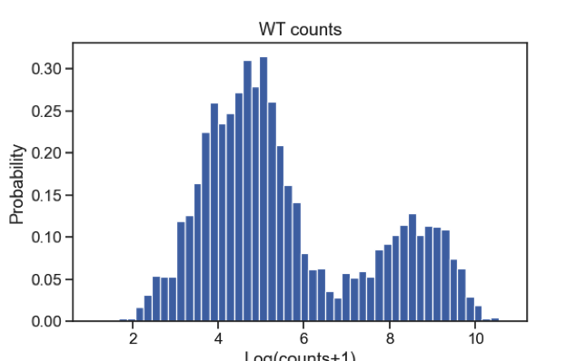

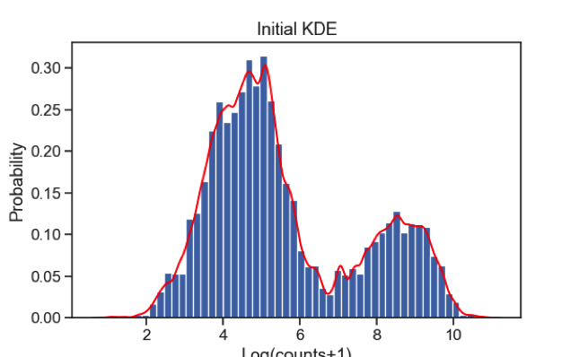

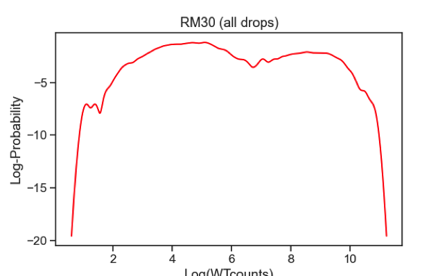

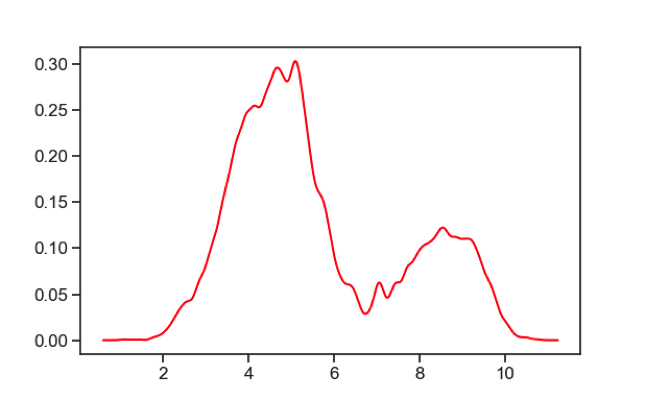

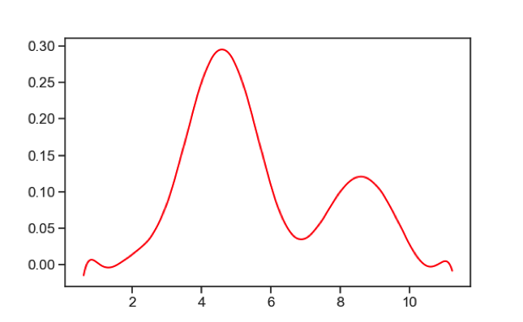

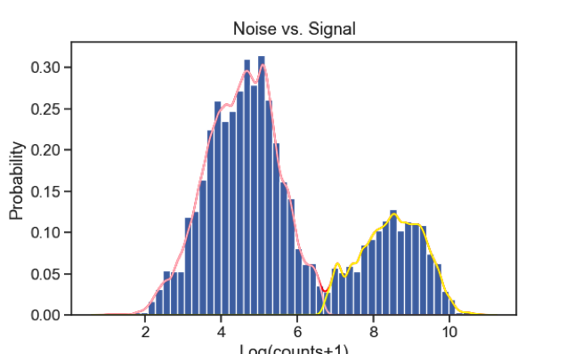

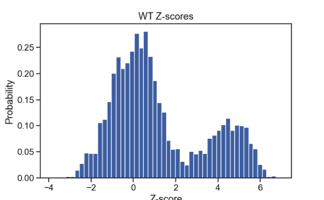

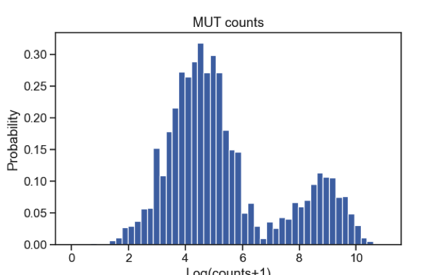

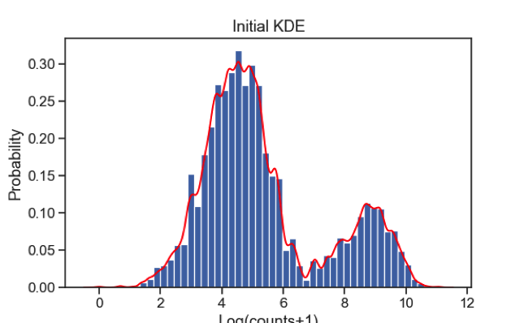

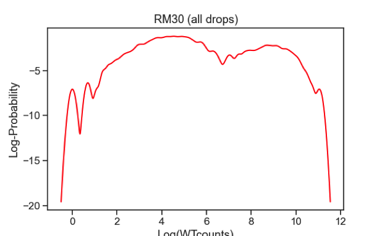

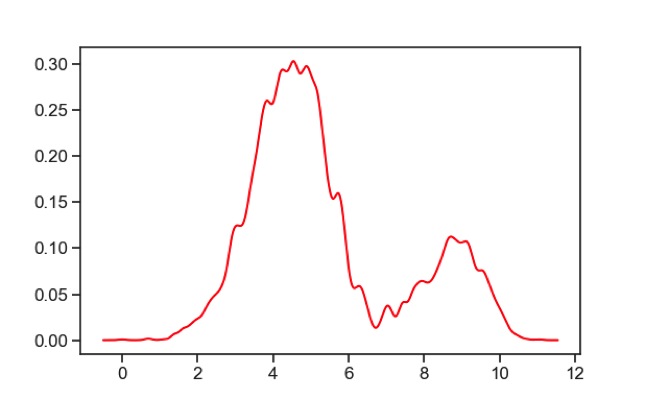

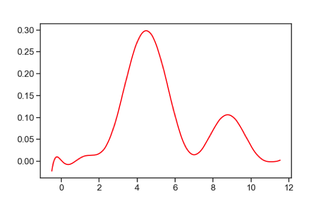

[4 more figures not shown]

```
Reading in file.
Number of cells: 4657
Noise correcting WT read counts.
5.3210505715729095
6.875730081223762
Optimization terminated successfully.
         Current function value: 0.028554
         Iterations: 14
         Function evaluations: 29
6.734723897917415
Noise mean, noise var:
4.536318113057001 0.8870008623680512
2.462512606706242
Noise correcting MUT read counts.
6.02166087787291
7.002238955397624
Optimization terminated successfully.
         Current function value: 0.025923
         Iterations: 13
         Function evaluations: 26
7.236701131357777
Noise mean, noise var:
4.43795266627485 1.0981572650587275
2.787402763976981
Performing quadrant genotyping.
Computing KNN-based clusters.
[1255, 979, 2419, 4]
Nearest neighbors: 18
Remove uncertain labels and re-label with self-training.
Label propagation completed in 4.77876854200008 seconds.
Proportion genotyped: (cluster method): 0.4945243719132489
Proportion genotyped: (quadrant method): 0.4805668885548636
Quadrant labels:
Counter({'NA': 2419, 'WT': 1255, 'MUT': 979, 'HET': 4})
Cluster labels:
Counter({'NA': 2354, 'WT': 1260, 'MUT': 1042, 'HET': 1})
All analysis complete!
Total time to execute: 15.166560624999875
```

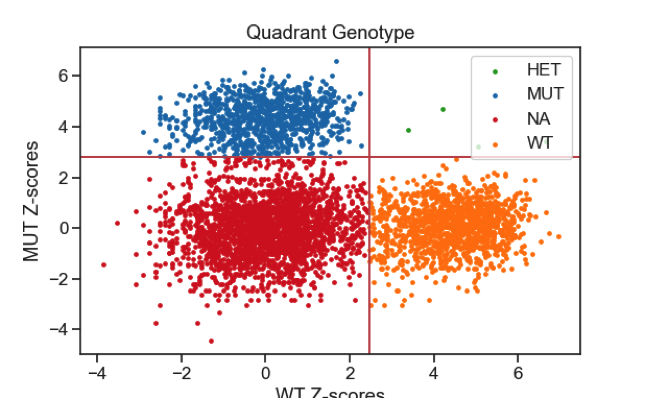

The output of the function is a data frame containing the assigned genotypes based on either the quadrant genotype (quadrant_class) or the predicted genotype (genotype_pred):

```r
head(genotypes)
```

|  | WTcount | MUTcount | transf_WT | transf_MUT | quadrant_class | genotype_pred |
| --- | --- | --- | --- | --- | --- | --- |
| RM30#AACATCGAGGCCTCGT-1 | 2383 | 136 | 3.62948 | 0.48007 | WT | WT |
| RM30#CCCACATAGGCGATTG-1 | 112 | 2920 | 0.21402 | 3.52737 | MUT | MUT |
| RM30#CAGCTAATCTATCCTA-1 | 311 | 771 | 1.35165 | 2.20207 | NA | NA |
| RM30#GCACGGTGTCGAGGAT-1 | 548 | 2582 | 1.98463 | 3.40490 | MUT | MUT |
| RM30#CCAATGACAGGCAGAT-1 | 214 | 17655 | 0.93455 | 5.31923 | MUT | MUT |
| RM30#TTGTTGTCAGGTAACG-1 | 251 | 493 | 1.11242 | 1.75743 | NA | NA |

This data frame can be added to the metadata of a Signac or ArchR object to perform downstream analysis. The “genotype_pred” column contains the assigned genotype label after noise correction and labeling.